# Iteration, with WPA10 and solutions (ds4psy)

Hansjörg Neth, SPDS, uni.kn

2019 07 08

# Introduction

This file contains **essential commands** from [Chapter 21: Iteration](https://r4ds.had.co.nz/iteration.html) of the textbook [r4ds](http://r4ds.had.co.nz) and corresponding examples and exercises. A command is considered “essential” when you really need to *know* it and need to know *how to use* it to succeed in this course.

All [ds4psy](http://rpository.com/ds4psy/) essentials so far:

| Nr. | Topic |
| --- | --- |
| 0. | [Syllabus](http://rpository.com/ds4psy/) |
| 1. | [Basic R concepts and commands](http://rpository.com/ds4psy/essentials/basics.html) |
| 2. | [Visualizing data](http://rpository.com/ds4psy/essentials/visualize.html) |
| 3. | [Transforming data](http://rpository.com/ds4psy/essentials/transform.html) |
| 4. | [Exploring data (EDA)](http://rpository.com/ds4psy/essentials/explore.html) |
| 5. | [Tibbles](http://rpository.com/ds4psy/essentials/tibbles.html) |
| 6. | [Importing data](http://rpository.com/ds4psy/essentials/import.html) |
| 7. | [Tidying data](http://rpository.com/ds4psy/essentials/tidy.html) |
| 8. | [Joining data](http://rpository.com/ds4psy/essentials/join.html) |
| 9. | [Functions](http://rpository.com/ds4psy/essentials/function.html) |
| 10. | **Iteration** [*](http://rpository.com/ds4psy/essentials/iteration.html) |
| +. | [Datasets](http://rpository.com/ds4psy/essentials/datasets.html) |

## Course coordinates

- PSY-15150, at the [University of Konstanz](https://www.uni-konstanz.de/) by [Hansjörg Neth](http://neth.de/) (h.neth@uni.kn, [SPDS](https://www.spds.uni-konstanz.de/), office D507).
- Summer 2019: Mondays, 15:15–16:45, D435.
- Links to current [course syllabus](http://rpository.com/ds4psy/) | [ZeUS](https://zeus.uni-konstanz.de:443/hioserver/pages/startFlow.xhtml?_flowId=detailView-flow&unitId=5101&periodId=179&navigationPosition=hisinoneLehrorganisation,examEventOverviewOwn) | [Ilias](https://ilias.uni-konstanz.de/ilias/goto_ilias_uni_crs_863036.html)
- [ds4psy](https://bookdown.org/hneth/ds4psy/%3E) essentials and WPAs

## Preparations

Create an R script (`.R`) or an R-Markdown file (`.Rmd`) and load the R packages of the **tidyverse**. (**Hint:** Structure your script by inserting spaces, meaningful comments, and sections.)

```r
## Iteration | ds4psy
## 2019 01 31
## ----------------------------

## Preparations: ----------

library(tidyverse)

## 1. Topic: ----------

# etc.

## End of file (eof). ----------
```

To use [R Markdown](https://rmarkdown.rstudio.com), create a corresponding file and save it with the `.Rmd` extension (e.g., by selecting `File > New File > R Markdown`). For instructions on combining text and code, see [Chapter 27: R Markdown](https://r4ds.had.co.nz/r-markdown.html) of our textbook, or use one of the following templates:

- minimal template: `rmd_template_s` [in .Rmd | .html format]
- medium template: `rmd_template_m` [in .Rmd | .html format]
- explicit explanations: `Rmarkdown_basics` [in .Rmd | .html format]

**Hint:** Try to *knit* your `.Rmd` file immediately after saving it and marvel at the beauty of the resulting `.html`-file. If this works, keep doing this routinely from now on, putting all your R-code into code chunks, and any text (like headings or conclusions) that describes or explains what you are doing outside of them. From now on, you can share your `.html` output files, rather than your `.Rmd` source files when showing off your R and data science skills.

# Iteration

Defining *iteration* := doing things repeatedly. The repetition of a procedure or process.

## Loops

[output not shown]

### Using a `for` loop

Asking and answering 3 questions:

1. *body*: What is the task performed in the loop?
2. *sequence*: Over which sequence should be iterated? *How many* iterations are there?
3. *output*: What is the *result* of the loop: What *type* of object and *how many* instances?

After answering these questions, a `for` loop can be designed in reverse order (from output to body):

```r
# (a) prepare output:
output <- vector(<type>, length(start:end))

# (b) for loop:
for (i in start:end} {                    # sequence

  result_i <- <solve task for i-th case>  # body: solve task
  output[[i]] <- result_i                 #       collect results in output

}

# (c) use output:
output
```

#### Loops for iteration

Assuming we know how often we want to do something.

Example: Compute square number of integers from 1 to 10.

1. *body*: Square of some number `i`.
2. *sequence*: `i` from 1 to 10.
3. *output*: A vector of 10 numbers.

Implementation:

```r
# (a) prepare output:
output <- vector("double", length(1:10))

# (b) for loop:
for (i in 1:10) {

  sq <- i^2
  print(paste0("i = ", i, ": sq = ", sq))  # for debugging
  output[[i]] <- sq

}
```

```
#> [1] "i = 1: sq = 1"
#> [1] "i = 2: sq = 4"
#> [1] "i = 3: sq = 9"
#> [1] "i = 4: sq = 16"
#> [1] "i = 5: sq = 25"
#> [1] "i = 6: sq = 36"
#> [1] "i = 7: sq = 49"
#> [1] "i = 8: sq = 64"
#> [1] "i = 9: sq = 81"
#> [1] "i = 10: sq = 100"
```

```r
# (c) use output:
output
```

```
#>  [1]   1   4   9  16  25  36  49  64  81 100
```

**Note:** In the `for` loop, we use `output[[i]]`, rather than `output[i]` to refer to the `i`-th element of `output` . Actually, using a single `[]` would have worked as well, but the double `[[]]` makes it clear that we want to remove a level of the hierarchy and assign something to a single element of `output`. (See [Ch. 20.5.2 Subsetting recursive vectors (lists)](https://r4ds.had.co.nz/vectors.html#subsetting-1) for more details on this distinction.)

#### Loops over data

In the context of data science, we often want to iterate over (rows or columns) of data tables. Let’s load some data to work with:

```r
## Load data:
# tb <- read_csv2("../data/tb.csv")  # from local file
tb <- read_csv2("http://rpository.com/ds4psy/data/tb.csv")  # from local file

# inspect tb:
dim(tb)  # 100 cases x 5 variables
```

```
#> [1] 100   5
```

```r
head(tb)
```

```
#> # A tibble: 6 x 5
#>      id   age height shoesize    IQ
#>   <dbl> <dbl>  <dbl>    <dbl> <dbl>
#> 1     1    21    173       38    89
#> 2     2    26    193       43    93
#> 3     3    24    171       41    92
#> 4     4    32    191       43    97
#> 5     5    26    156       36   110
#> 6     6    28    172       34   117
```

Suppose we wanted to obtain the means of the variables from `age` to `IQ`. We could call the `mean` function for each descired variable. Thus, repeating this call for each variable would be:

```r
# (a) Means: ----
mean(tb$age)
```

```
#> [1] 26.29
```

```r
mean(tb$height)
```

```
#> [1] 177.78
```

```r
mean(tb$shoesize)
```

```
#> [1] 39.05
```

```r
mean(tb$IQ)
```

```
#> [1] 104.85
```

However, the statement “for each variable” in the previous sentence shows that we are dealing with an instance of *iteration* here. When dealing with computers, *repetition* of identical steps or commands is a signal that there are more efficient ways to accomplish the same task.

How could we use a for loop here? To design this loop, we need to answer our 3 questions from above:

1. *body*: We want to compute the mean of 4 columns (`age` to `IQ`) in `tb`.
2. *sequence*: We want to iterate over columns 2 to 5 (i.e., 4 iterations).
3. *output*: The *result* or the loop is a vector of type “double”, containing 4 elements.

#### Notes

- We remove the 1st column, as no computation is needed for it.
- The i-th column of tibble `tb` (or data frame `df`) can be accessed via `tb[[i]]` (or `df[[i]]`).

```r
# Prepare data:
tb_2 <- tb %>% select(-1)
tb_2
```

```
#> # A tibble: 100 x 4
#>      age height shoesize    IQ
#>    <dbl>  <dbl>    <dbl> <dbl>
#>  1    21    173       38    89
#>  2    26    193       43    93
#>  3    24    171       41    92
#>  4    32    191       43    97
#>  5    26    156       36   110
#>  6    28    172       34   117
#>  7    20    166       35   107
#>  8    31    172       34   110
#>  9    18    192       32    88
#> 10    22    176       39   111
#> # … with 90 more rows
```

```r
# (a) prepare output:
output <- vector("double", 4)

# (b) for loop:
for (i in 1:4){

  mn <- mean(tb_2[[i]])

  output[[i]] <- mn

}

# (c) use output:
output
```

```
#> [1]  26.29 177.78  39.05 104.85
```

In the **tidyverse** the range of a `for` loop can be defined with a special function:

```r
seq_along(tb_2)  # loop through COLUMNS of a df/table
```

```
#> [1] 1 2 3 4
```

#### Practice

1. Rewrite the for loop to compute the means of columns 2 to 5 of `tb` (i.e., without simplifying `tb` to `tb_2` first).

#### Solution

We create a new output vector `output_2` and need to change 2 things:

- the column numbers of the `for` loop statement (from `1:4` to `2:5`).
- the index to which we assign our current mean `mn` should be decreased to `i - 1` (to assign the mean of column 2 to the 1st element of `output_2`).

```r
# Using data:
# tb

# (a) prepare output:
output_2 <- vector("double", 4)

# (b) for loop:
for (i in 2:5){

  mn <- mean(tb[[i]])

  output_2[[i - 1]] <- mn

}

# (c) use output:
output_2
```

```
#> [1]  26.29 177.78  39.05 104.85
```

```r
# Verify equality:
all.equal(output, output_2)
```

```
#> [1] TRUE
```

2. We have learned that creating a `for` loop requires knowing (a) the data type of the loop results and (b) a data structure than can collect these results. This is simple and straightforward if each `for` loop results in a single number, as then all results can be stored in a vector.

However, things get more complicated when `for` loops yield tables, lists, or plots, as outputs. Try creating similar `for` loops that return the `summary` and a histogram (using the **base** R function `hist`) of each variable in `tb` (or each variable of `tb_2`).

#### Solution

Creating a `summary`:

```r
# (b) Summary: ----
summary(tb$age)
```

```
#>    Min. 1st Qu.  Median    Mean 3rd Qu.    Max.
#>   15.00   22.00   24.50   26.29   30.25   46.00
```

```r
summary(tb$height)
```

```
#>    Min. 1st Qu.  Median    Mean 3rd Qu.    Max.
#>   150.0   171.8   177.0   177.8   185.0   206.0
```

```r
summary(tb$shoesize)
```

```
#>    Min. 1st Qu.  Median    Mean 3rd Qu.    Max.
#>   29.00   36.00   39.00   39.05   42.00   47.00
```

```r
s <- summary(tb$IQ)
s
```

```
#>    Min. 1st Qu.  Median    Mean 3rd Qu.    Max.
#>    85.0    97.0   104.0   104.8   113.0   145.0
```

```r
# What type of object is s?
typeof(s)     # "double"
```

```
#> [1] "double"
```

```r
is.vector(s)  # FALSE
```

```
#> [1] FALSE
```

```r
is.table(s)   # TRUE
```

```
#> [1] TRUE
```

The following `for` loop is almost identical to the one (computing `mean` of columns 2:5 of `tb`) above. However, we initialize the `summaries` vector to a `mode = "list"`, which allows storing more complex objects in a vector:

```r
# Loop:
# (a) prepare output:
summaries <- vector(mode = "list", length = 4)  # initialize to a vector of lists!

# (b) for loop:
for (i in 2:5){

  sm <- summary(tb[[i]])

  summaries[[i - 1]] <- sm

}

# (c) use output:
summaries  # print summaries:
```

```
#> [[1]]
#>    Min. 1st Qu.  Median    Mean 3rd Qu.    Max.
#>   15.00   22.00   24.50   26.29   30.25   46.00
#>
#> [[2]]
#>    Min. 1st Qu.  Median    Mean 3rd Qu.    Max.
#>   150.0   171.8   177.0   177.8   185.0   206.0
#>
#> [[3]]
#>    Min. 1st Qu.  Median    Mean 3rd Qu.    Max.
#>   29.00   36.00   39.00   39.05   42.00   47.00
#>
#> [[4]]
#>    Min. 1st Qu.  Median    Mean 3rd Qu.    Max.
#>    85.0    97.0   104.0   104.8   113.0   145.0
```

Histogram:

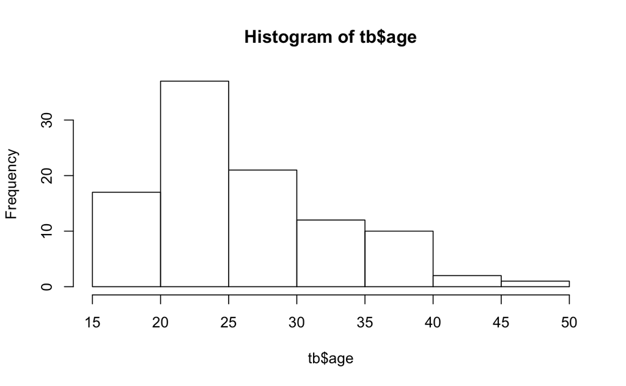

```r
# (c) Histogram: ----
hist(tb$age)
```

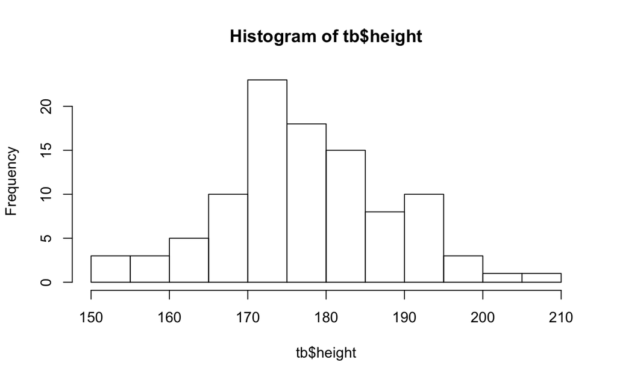

```r
hist(tb$height)
```

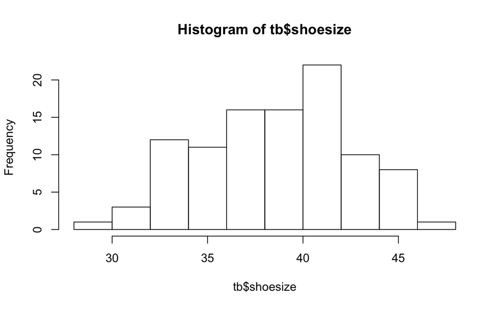

```r
hist(tb$shoesize)
```

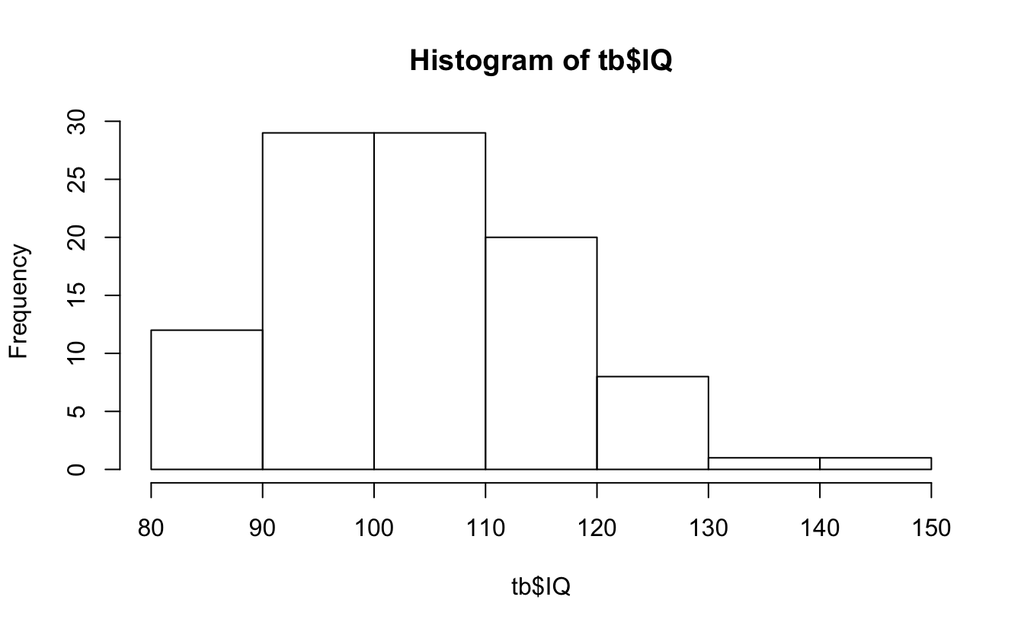

```r
h <- hist(tb$IQ)
```

```r
h
```

```
#> $breaks
#> [1]  80  90 100 110 120 130 140 150
#>
#> $counts
#> [1] 12 29 29 20  8  1  1
#>
#> $density
#> [1] 0.012 0.029 0.029 0.020 0.008 0.001 0.001
#>
#> $mids
#> [1]  85  95 105 115 125 135 145
#>
#> $xname
#> [1] "tb$IQ"
#>
#> $equidist
#> [1] TRUE
#>
#> attr(,"class")
#> [1] "histogram"
```

```r
typeof(h) # list
```

```
#> [1] "list"
```

```r
# As loop:
tb_2
```

```
#> # A tibble: 100 x 4
#>      age height shoesize    IQ
#>    <dbl>  <dbl>    <dbl> <dbl>
#>  1    21    173       38    89
#>  2    26    193       43    93
#>  3    24    171       41    92
#>  4    32    191       43    97
#>  5    26    156       36   110
#>  6    28    172       34   117
#>  7    20    166       35   107
#>  8    31    172       34   110
#>  9    18    192       32    88
#> 10    22    176       39   111
#> # … with 90 more rows
```

```r
names(tb_2[1])
```

```
#> [1] "age"
```

```
#> [1] 1
```

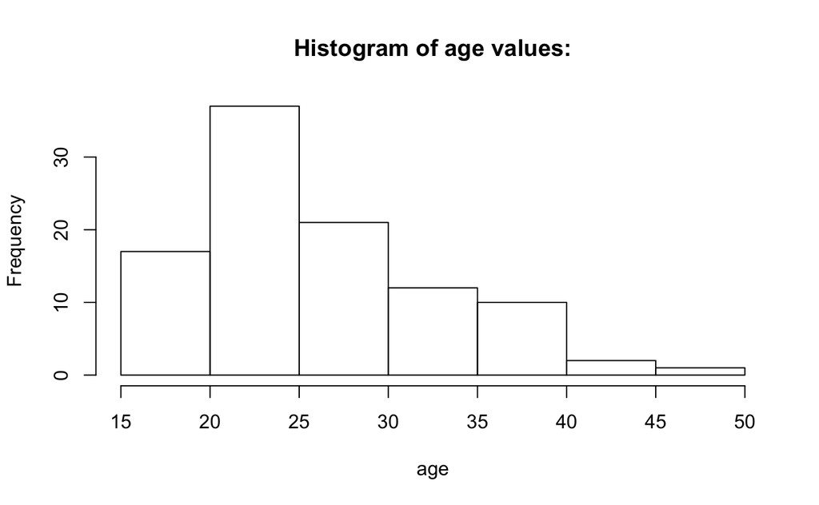

```
#> [1] 2
```

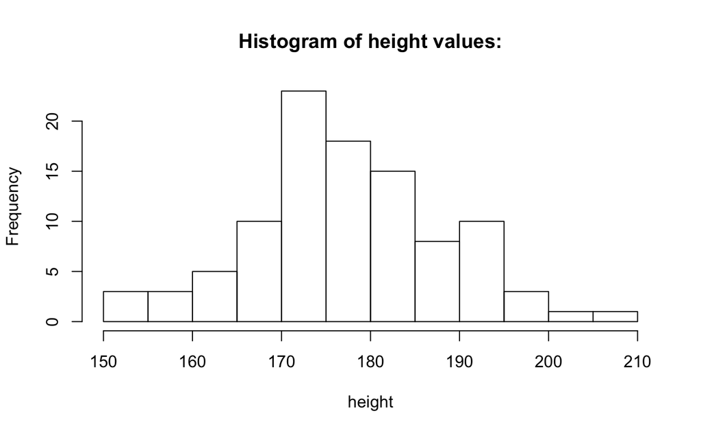

```
#> [1] 3
```

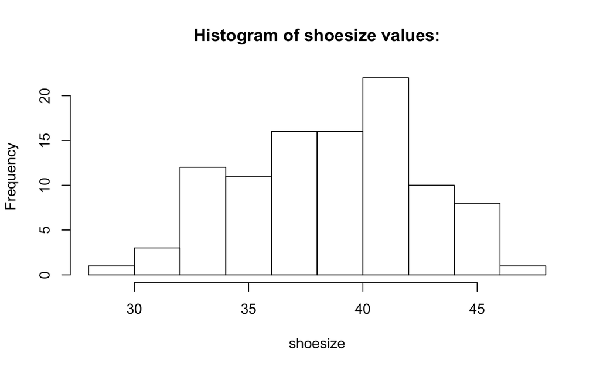

```
#> [1] 4
```

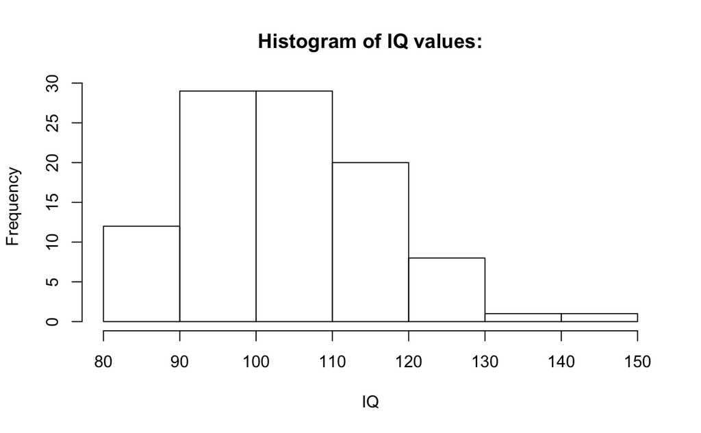

```r
hist(tb_2[[1]], main = paste0("Histogram of ", names(tb_2[1]), " values:"), xlab = names(tb_2[1]))

# With loop:
out <- vector("list", 4)

for (i in seq_along(tb_2)) {  # loop through COLUMNS of tb_2:

  print(i)
  var_name <- names(tb_2[i])
  title <- paste0("Histogram of ", var_name, " values:")
  x_lab <- var_name
  out[[i]] <- hist(tb_2[[i]], main = title, xlab = x_lab)

}
```

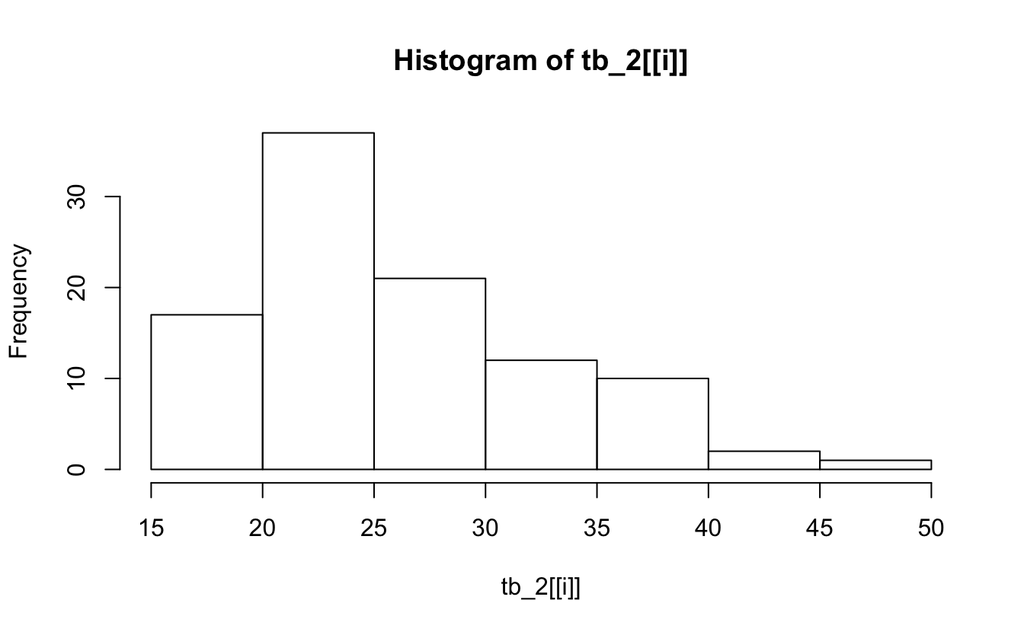

```r
plot(out[[1]])
```

### For loop variations

We can distinguish between 4 variations of the basic theme of the for loop:

#### 1. Modifying an existing object, instead of creating a new object

Example: Rescale every column of a table (tibble or data frame).

```r
set.seed(1)  # for reproducible results

tb <- tibble(
  a = rnorm(10),
  b = rnorm(10),
  c = rnorm(10),
  d = rnorm(10)
)
tb
```

```
#> # A tibble: 10 x 4
#>         a       b       c       d
#>     <dbl>   <dbl>   <dbl>   <dbl>
#>  1 -0.626  1.51    0.919   1.36
#>  2  0.184  0.390   0.782  -0.103
#>  3 -0.836 -0.621   0.0746  0.388
#>  4  1.60  -2.21   -1.99   -0.0538
#>  5  0.330  1.12    0.620  -1.38
#>  6 -0.820 -0.0449 -0.0561 -0.415
#>  7  0.487 -0.0162 -0.156  -0.394
#>  8  0.738  0.944  -1.47   -0.0593
#>  9  0.576  0.821  -0.478   1.10
#> 10 -0.305  0.594   0.418   0.763
```

```r
# Define rescale01 function:
rescale01 <- function(x) {
  rng <- range(x, na.rm = TRUE)
  (x - rng[1]) / (rng[2] - rng[1])
}
```

1. In 4 separate steps:

```r
df <- tb  # copy

# (a) each column individually:
df$a <- rescale01(df$a)
df$b <- rescale01(df$b)
df$c <- rescale01(df$c)
df$d <- rescale01(df$d)

df
```

```
#> # A tibble: 10 x 4
#>          a     b     c     d
#>      <dbl> <dbl> <dbl> <dbl>
#>  1 0.0860  1     1     1
#>  2 0.419   0.699 0.953 0.466
#>  3 0       0.428 0.710 0.645
#>  4 1       0     0     0.484
#>  5 0.479   0.896 0.897 0
#>  6 0.00624 0.582 0.665 0.352
#>  7 0.544   0.590 0.630 0.359
#>  8 0.647   0.848 0.178 0.482
#>  9 0.581   0.815 0.520 0.905
#> 10 0.218   0.754 0.828 0.782
```

2. Using a loop to modify an existing object:

Answers to our 3 questions:

1. *body*: apply `rescale01()` to every column of `tb`.
2. *sequence*: A list of columns (i.e., iterate over each column with `seq_along(tb)`).
3. *output*: `tb` (i.e., identical to the input).

```r
# (b) loop that modifies an existing object:
df2 <- tb  # copy

for (i in seq_along(df2)) {

  df2[[i]] <- rescale01(df2[[i]])

}

# Output:
df2
```

```
#> # A tibble: 10 x 4
#>          a     b     c     d
#>      <dbl> <dbl> <dbl> <dbl>
#>  1 0.0860  1     1     1
#>  2 0.419   0.699 0.953 0.466
#>  3 0       0.428 0.710 0.645
#>  4 1       0     0     0.484
#>  5 0.479   0.896 0.897 0
#>  6 0.00624 0.582 0.665 0.352
#>  7 0.544   0.590 0.630 0.359
#>  8 0.647   0.848 0.178 0.482
#>  9 0.581   0.815 0.520 0.905
#> 10 0.218   0.754 0.828 0.782
```

```r
# Verify equality:
all.equal(df, df2)
```

```
#> [1] TRUE
```

#### 2. Looping over names or values, instead of indices

So far, we used `for loop` to loop over *numeric indices* of `x` with `for (i in seq_along(x))`, and then extracted the `i`-th value of `x` with `x[[i]]`.

There are 2 additional common loop patterns:

1. loop over the *elements* of `x` with `for (x in xs)`: useful when only caring about side effects
2. loop over the *names* of `x` with `for (nm in names(xs))`: useful when names are needed for files or plots.

Whenever creating named output, make sure also provide *names* to the results vector:

```r
x <- 1:3

results <- vector("list", length(x))
names(results) <- names(x)

results
```

Note that the basic iteration over the numeric indices is the most general form, because given a position we can extract both the current name and the current value:

```r
x <- 1:3

for (i in seq_along(x)) {
  name  <- names(x)[[i]]
  value <- x[[i]]
}
```

#### 3. Handling outputs of unknown length

- Problem: Knowing the number of iterations, but not knowing how long the output will be.

For example, imagine we knew the first `N = 1000` digits of pi (i.e., a series of digits `314159` etc.), but wanted to count how frequently a specific target subsequence (e.g., `target = 13`) occurs in this sequence.

The following code loads the first `N = 1000` digits of pi into a scalar character object `pi_1000`:

```r
# Data:
## Orig. data source <http://www.geom.uiuc.edu/~huberty/math5337/groupe/digits.html>
## pi_all <- readLines("./data/pi_100k.txt")               # from local data file
pi_data <- "http://rpository.com/ds4psy/data/pi_100k.txt"  # from online data file
pi_all <- readLines(pi_data)                               # read from online source

N <- 1000
pi_1000 <- paste0(substr(pi_all, 1, 1), substr(pi_all, 3, (N + 1)))  # skip the "." at position 2!
nchar(pi_1000)          # 1000 (qed)
```

```
#> [1] 1000
```

```r
substr(pi_1000, 1, 10)  # first 10 digits
```

```
#> [1] "3141592653"
```

The following code uses a for loop to answer the questions: How many times and at which positions does the `target <- 13` occur in `pi_1000`?

```r
# initialize:
count <- 0   # count number of occurrences
target <- 13
target_positions <- c()  # vector to store positions

# loop:
for (i in 1:(N-1)){

  # Current 2-digit sequence:
  digits_i <- substr(pi_1000, i, i+1)  # as character
  digits_i <- as.integer(digits_i)     # as integer

  if (digits_i == target){

    count <- count + 1  # increment count
    target_positions <- c(target_positions, i)  # add the current i to pi_3

  } # end if.

}

# Results:
count
```

```
#> [1] 12
```

```r
target_positions
```

```
#>  [1] 111 282 364 382 526 599 628 735 745 760 860 972
```

```r
count == length(target_positions)
```

```
#> [1] TRUE
```

The answers are that 13 occurs 12 times in `pi_1000`. Its 1st occurrence is at position 111 and its 12-th occurrence at position 972.

Note that we could specify the number of iterations (i.e., `N - 1` loops, from 1 to 999), but not the number of elements in `target_positions`.

Incrementing the `target_positions` vector by `i` every time a new target is found — by `target_positions <- c(target_positions, i)` — is quite slow and inefficient. However, this is not problematic as long as we only do this once and for a relatively small problem (like a loop with 999 iterations).

A more efficient solutions could initialize `target_positions` to a *list* (which can take any data object as an element) and then store any instance of finding the `target` at the `i`-th position of `pi_1000` as the `i`-th instance of the list. Once the loop is finished, we can use `unlist()` to flatten the list to a vector:

```r
# initialize:
count <- 0   # count number of occurrences
target <- 13
target_positions <- vector("list", (N - 1))  # empty list (of N - 1 elements) to store positions

# loop:
for (i in 1:(N-1)){

  # Current 2-digit sequence:
  digits_i <- substr(pi_1000, i, i+1)  # as character
  digits_i <- as.integer(digits_i)     # as integer

  if (digits_i == target){

    count <- count + 1        # increment count
    target_positions[i] <- i  # add the current i to pi_3

  } # end if.

}

# Results:
count
```

```
#> [1] 12
```

```r
# target_positions # is a list with mostly NULL
target_positions <- unlist(target_positions)  # flatten list to vector (removing NULL elements)
target_positions
```

```
#>  [1] 111 282 364 382 526 599 628 735 745 760 860 972
```

```r
count == length(target_positions)
```

```
#> [1] TRUE
```

This way, we could initialize the length of `target_positions` before entering the for loop. This made it possible to assign any new target to `target_positions[i]`, but made the list much larger than it actually needed to be. The advantages and disadvantages of these different options should be considered for the specific problem at hand.

#### 4. Handling sequences of unknown length

- Problem: The number of iterations is not known in advance.
- Solution: Use a `while` loop, with a `condition` to stop the loop.

Sometimes we cannot know in advance how many iterations our loop should run for. This is common when dealing with random outcomes or running simulations that need to reach some threshold value to stop.

We can address these problems with a `while` loop.  
Actually, a `while` loop is simpler than a `for` loop because it only has 2 components, a condition and a body:

```r
while (condition) {
  # body
}
```

A `while` loop is also more general than a `for` loop because we can write any `for` loop as a `while` loop, but not vice versa. For instance, any `for` loop with `N` steps:

```r
for (i in 1:N){

  # loop body

}
```

can be re-written as a `while` loop that uses a counter variable `i` for the number of iterations and a condition that the maximum number of steps `N` must not be exceeded:

```r
i <- 1  # initialize counter

while (i <= N){

  # loop body

  i <- i + 1  # increment position counter

}
```

As this requires explicit maintenance (here: the initialization and incrementation of a counter), we prefer using `for` loops when the number of iterations is known in advance.

However, we often do not know in advance how many iterations we will need. For instance, let’s ask ourselves the following question:

- At which position in the first 1000 digits of pi do we first encounter the subsequence `13`?

Actually, we do know the answer to this problem from `target_positions` above: The 1st occurrence of 13 in `pi_1000` is at position 111. Knowing a solution makes this a good practice problem.

Assuming that we know nothing else of the sequence, we cannot do that sort of iteration with the `for` loop (unless we loop over the entire sequence, as we did above). The following `while` loop solves this task by incrementally increasing `i` to inspect the corresponding digits (at positions `i` and `i + 1`) of `pi_1000` as long as we meet the condition `digits_i != target`:

```r
# Data:
# pi_1000  # 1000 digits of pi (from above)

target <- 13
i <- 1  # initialize position counter
digits_i <- as.integer(substr(pi_1000, i, i+1)) # 2-digit integer starting at position i

while (digits_i != target){

  i <- i + 1  # increment position counter
  digits_i <- as.integer(substr(pi_1000, i, i+1)) # 2-digit integer starting at position i

} # end while

# position of 1st target:
i
```

```
#> [1] 111
```

A danger of `while` loops is that they may never stop. For instance, if we asked:

- At which position in the first 1000 digits of pi do we first encounter the subsequence `999`?

we could slightly modify our code above (to accommodate `digits_i` to look for 3-digit number):

```r
# Data:
# pi_1000  # 1000 digits of pi (from above)

target <- 999    # 3-digit target (found)
# target <- 123  # alternative target (yielding error)

i <- 1  # initialize position counter
digits_i <- as.integer(substr(pi_1000, i, i+2)) # 3-digit integer starting at position i

while (digits_i != target){

  i <- i + 1  # increment position counter
  digits_i <- as.integer(substr(pi_1000, i, i+2)) # 3-digit integer starting at position i

} # end while

# position of 1st target:
i
```

```
#> [1] 763
```

The answer is: The digits 999 first appear in `pi_1000` at position 763.

However, if we changed our target to `123` to ask the analog question:

- At which position in the first 1000 digits of pi do we first encounter the subsequence `123`?

the same `while` loop would encounter an error message:

```r
Error in while (digits_i != target) { :
  missing value where TRUE/FALSE needed
```

The source of this error becomes obvious when realizing that `i` is set to a value of 1001: We simply did not find an instance of `123` in the first 1000 digits of pi and the counter is trying to access its 1001. digit, which is undefined (`NA`) and hence causes an error in our condition (`digits_i != target`).

To prevent this sort of error, we could modify our condition to also stop the `while` loop after the maximum number of possible steps has been reached. In our case, the `while` loop does only makes sense as long as we do not exceed the number of characters in `pi_1000`, so that we can add the requirement `(i <= nchar(pi_1000))` as an additional (conjunctive, i.e., using `&&`) test to our condition:

```r
# Data:
# pi_1000  # 1000 digits of pi (from above)

# target <- 999  # 3-digit target (found)
target <- 123    # alternative target (not found)

i <- 1  # initialize position counter
digits_i <- as.integer(substr(pi_1000, i, i+2)) # 3-digit integer starting at position i

while ( (digits_i != target) && (i <= nchar(pi_1000)) ){

  i <- i + 1  # increment position counter
  digits_i <- as.integer(substr(pi_1000, i, i+2)) # 3-digit integer starting at position i

} # end while

# position of 1st target:
i
```

```
#> [1] 1001
```

This way, the `while` loop is limited to a maximum of `nchar(pi_1000) =` 1000 iterations. If the counter `i` shows an impossible value of 1001, we can conclude that the `target` sequence was not found.

#### Practice

- Combine a `for` loop and a `while` loop to find the positions of the first 3 occurrences of `13` in `pi_1000`.

**Hint:** Inspecting `target_positions` (computed above) tells you the solution. But it’s still instructive to combine both type of loops to solve this problem.

```r
# Data:
# pi_1000

first_3 <- rep(NA, 3)  # initialize output
target <- 13
i <- 1  # initialize position counter
digits_i <- as.integer(substr(pi_1000, i, i+1)) # 2-digit integer starting at position i

for (n in seq_along(first_3)){

  while (digits_i != target){

      i <- i + 1  # increment position counter
      digits_i <- as.integer(substr(pi_1000, i, i+1)) # 2-digit integer starting at position i

  } # end while loop.

  first_3[n] <- i  # store current position

  i <- i + 1  # increment position counter
  digits_i <- as.integer(substr(pi_1000, i, i+1)) # 2-digit integer starting at position i

} # end for loop,

# Solution:
first_3
```

```
#> [1] 111 282 364
```

```r
# Verify equality:
all.equal(first_3, target_positions[1:3])
```

```
#> [1] TRUE
```

## Functional programming

### For loops vs. functionals

In R, `for` loops are not as important as in most other programming languages, because R is a *functional* programming language. This means that it is possible to replace many `for` loops by wrapping up the body of a `for` loop in a function, and then call that function.

#### Example

Consider a simple data table `df`:

```r
# Data:
set.seed(1)  # for reproducible results

df <- tibble(a = rnorm(10),
             b = rnorm(10),
             c = rnorm(10),
             d = rnorm(10)
)

df
```

```
#> # A tibble: 10 x 4
#>         a       b       c       d
#>     <dbl>   <dbl>   <dbl>   <dbl>
#>  1 -0.626  1.51    0.919   1.36
#>  2  0.184  0.390   0.782  -0.103
#>  3 -0.836 -0.621   0.0746  0.388
#>  4  1.60  -2.21   -1.99   -0.0538
#>  5  0.330  1.12    0.620  -1.38
#>  6 -0.820 -0.0449 -0.0561 -0.415
#>  7  0.487 -0.0162 -0.156  -0.394
#>  8  0.738  0.944  -1.47   -0.0593
#>  9  0.576  0.821  -0.478   1.10
#> 10 -0.305  0.594   0.418   0.763
```

Assume that our goal is getting the mean of every column of `df`. The standard solution for this task is using a `for` loop:

```r
# prepare output vector:
out <- vector("double", ncol(df))

# for loop over columns i:
for (i in seq_along(df)) {

  out[[i]] <- mean(df[[i]])

}

out
```

```
#> [1]  0.1322028  0.2488450 -0.1336732  0.1207302
```

As we will want to compute the means of every column pretty frequently, we abstract the `for` loop into a dedicated `col_mean` function:

```r
col_mean <- function(data) {

  out <- vector("double", length(data))

  for (i in seq_along(data)) {

    out[i] <- mean(data[[i]])  # apply function to i-th column of df

  }

  return(out)
}

# Check:
col_mean(df)
```

```
#> [1]  0.1322028  0.2488450 -0.1336732  0.1207302
```

But now we are no longer satisfied with the *mean*, but also want the *median* and *standard deviation* of every column. Of course we could write analog functions `col_median()` and `col_sd()`, but they would only differ in 1 line from `col_mean` above. Hence, what we really would want is that we could *pass a function* (like `mean` or `median`) to another function — which is exactly what we will learn to do next.

#### Motivation: Generalizing functions

Consider the following 3 functions:

```r
f1 <- function(x) {abs(x - mean(x)) ^ 1}
f2 <- function(x) {abs(x - mean(x)) ^ 2}
f3 <- function(x) {abs(x - mean(x)) ^ 3}
```

The 3 functions only vary in their last digit. Given this degree of duplicated code, we would make the last element an *additional argument* to a more general function:

```r
f <- function(x, i) {abs(x - mean(x)) ^ i}
```

By doing this, we have reduced the amount of code, the corresponding chance of errors, and made it easier to generalise to new situations.

#### Application: Using functions as arguments to functions

We can achieve exactly the same thing for 3 similar functions — like `col_mean()`, `col_median()`, and `col_sd()` — by adding an argument to a function that supplies the *function* to apply to each column:

```r
col_summary <- function(data, fun) {

  # prepare vector of outputs:
  out <- vector("double", length(data))

  # loop over data:
  for (i in seq_along(data)) {

    # apply fun to the i-th element of data:
    out[i] <- fun(data[[i]])  # !!!

  } # end for loop.

  return(out)

}

# Repeat use of col_mean (from above):
col_summary(df, fun = mean) # Note: same functionality/results as above.
```

```
#> [1]  0.1322028  0.2488450 -0.1336732  0.1207302
```

```r
# New uses:
col_summary(df, fun = median)
```

```
#> [1]  0.256575548  0.491872279  0.009218122 -0.056559219
```

```r
col_summary(df, fun = sd)
```

```
#> [1] 0.7805860 1.0695148 0.9556076 0.8085646
```

The idea of passing a *function* (like `mean` or `median`) as an *argument* (here: `fun`) to another *function* (here: `col_summary`) is an extremely powerful idea, and it one reason for calling R a *functional* programming language.

## Replacing loops by `apply` and **purrr**

The `apply` family of functions of **base** R and the `map` functions of the **purrr** package provide functions that eliminate the need for many `for` loops.

Note that using `apply` or `map` is not necessarily faster than using `for` loops. The chief benefit of using these functions is not speed, but *clarity*: They make code easier to write and read.

### Using `apply`

The `base::apply` family of functions in (i.e., `apply`, `lapply`, `tapply`, etc.) replaces `for` loops by applying a function to designated parts of a (rectangular) data structure. To accomplish this, `apply` takes the following arguments:

- `X` argument takes an array or matrix (i.e., rectangular data);
- `MARGIN` argument: `1` = rows, `2` = columns;
- `FUN` is the function to be applied.

#### Examples

We can use `base::apply` to solve the problems addressed by `col_summary` above:

```r
# Data:
# df # from above
dim(df)  # 10 rows, 4 columns:
```

```
#> [1] 10  4
```

```r
# apply FUN to columns:
apply(X = df, MARGIN = 2, FUN = mean)    # mean of every column
```

```
#>          a          b          c          d
#>  0.1322028  0.2488450 -0.1336732  0.1207302
```

```r
apply(X = df, MARGIN = 2, FUN = median)  # median of every column
```

```
#>            a            b            c            d
#>  0.256575548  0.491872279  0.009218122 -0.056559219
```

```r
apply(X = df, MARGIN = 2, FUN = sd)      # SD of every column
```

```
#>         a         b         c         d
#> 0.7805860 1.0695148 0.9556076 0.8085646
```

In this call, `MARGIN = 2` instructed `apply` to apply some function `FUN` to each *column* of `X`. Changing the `MARGIN` argument `MARGIN = 1` will apply `FUN` to each *row* of `X`:

```r
# apply FUN to rows:
apply(X = df, MARGIN = 1, FUN = mean)    # mean of every row
```

```
#>  [1]  0.79074607  0.31320878 -0.24865815 -0.66564396  0.17430122
#>  [6] -0.33413132 -0.01971167  0.03802378  0.50471947  0.36740756
```

```r
apply(X = df, MARGIN = 1, FUN = median)  # median of every row
```

```
#>  [1]  1.13882846  0.28674328 -0.27333780 -1.02157837  0.47466676
#>  [6] -0.23556165 -0.08599288  0.33950565  0.69850127  0.50592144
```

```r
apply(X = df, MARGIN = 1, FUN = sd)      # SD of every row
```

```
#>  [1] 0.9776398 0.3722034 0.5752509 1.7923824 1.0852032 0.3669620 0.3723940
#>  [8] 1.0949578 0.6893583 0.4701560
```

**Note** some variants of `apply`:

- `lapply` returns a *list* of the same length as `X`, each element of which is the result of applying `FUN` to the corresponding element of `X`.
- See also `sapply` and `vapply` for simplifying arrays and returning vectors.

### Using **purrr**

The **purrr** package provides modern and more consistent versions of `apply`.

The main goal of using **purrr** functions (instead of `for` loops) is to break common list manipulation challenges into smaller and independent pieces. This strategy involves 2 steps, each of which scales down the problem:

1. Solving the problem for a *single element* of the list.  
   Once we have solved that problem, **purrr** takes care of generalising the solution to every element in the list.
2. Breaking a complex problem down into *smaller sub-problems* that allow us to advance towards a solution.  
   With **purrr**, we get many small pieces that we can compose together with the pipe (`%>%`).

This scaling-down strategy makes it easier to solve new problems and to understand our solutions to old problems when we re-read older code.

#### `map` functions

The pattern of looping over a vector, doing something to each element, and saving the results is so common that the **purrr** package provides a family of functions for it. There is a separate function for each type of output:

- `map()` makes a *list*.
- `map_lgl()` makes a *logical vector*.
- `map_int()` makes an *integer vector*.
- `map_dbl()` makes a *double vector*.
- `map_chr()` makes a *character vector*.

Each function takes a vector `.x` as input, applies a function `.f` to each element, and then returns a new vector that’s the same length (and has the same names) as the input vector. The type of the output vector is determined by the suffix of the `map` function (e.g., `map_chr` would return the output as a character vector).

#### Examples

Using map on the above example (with doubles as output):

```r
map_dbl(.x = df, .f = mean)
```

```
#>          a          b          c          d
#>  0.1322028  0.2488450 -0.1336732  0.1207302
```

```r
map_dbl(df, median)
```

```
#>            a            b            c            d
#>  0.256575548  0.491872279  0.009218122 -0.056559219
```

```r
map_dbl(df, sd)
```

```
#>         a         b         c         d
#> 0.7805860 1.0695148 0.9556076 0.8085646
```

#### Practice

- Predict the output of the following variants, then check your predictions:

```r
map(df, mean)
map_int(df, mean)
map_lgl(df, mean)
map_chr(df, mean)
```

#### Details

- Without the suffix `_dbl`, `map(df, sd)` returns a *list* (with an element for every column of `df`).
- With `map`, our focus is on the function/operation, not the bookkeeping of the `for` loop. This is even more obvious when using the pipe:

```r
df %>% map_dbl(mean)
```

```
#>          a          b          c          d
#>  0.1322028  0.2488450 -0.1336732  0.1207302
```

```r
df %>% map_dbl(median)
```

```
#>            a            b            c            d
#>  0.256575548  0.491872279  0.009218122 -0.056559219
```

```r
df %>% map_dbl(sd)
```

```
#>         a         b         c         d
#> 0.7805860 1.0695148 0.9556076 0.8085646
```

- `map` also uses the generic `...` argument to allow passing additional arguments to the function indicated by `.f`:

```r
map_dbl(df, mean, trim = 0.5)
```

```
#>            a            b            c            d
#>  0.256575548  0.491872279  0.009218122 -0.056559219
```

```r
map_dbl(df, sd, na.rm = FALSE)
```

```
#>         a         b         c         d
#> 0.7805860 1.0695148 0.9556076 0.8085646
```

- `map` preserves the names of `.x`:

```r
z <- list(x = 1:3, y = 4:5)
z
```

```
#> $x
#> [1] 1 2 3
#>
#> $y
#> [1] 4 5
```

```r
z %>% map_int(length)
```

```
#> x y
#> 3 2
```

#### Shortcuts

There are a few shortcuts to save typing in the `.f` argument of `map`.

Imagine we want to fit a linear model to each group in a dataset.

The following example splits the up the `mtcars` dataset in to 3 pieces (by value of cylinder) and fits the same linear model to each piece. The linear model is supplied as an *anonymous function*:

```r
mtcars %>%
  group_by(cyl) %>%
  count()
```

```
#> # A tibble: 3 x 2
#> # Groups:   cyl [3]
#>     cyl     n
#>   <dbl> <int>
#> 1     4    11
#> 2     6     7
#> 3     8    14
```

```r
models <- mtcars %>%
  split(.$cyl) %>%                            # split data into 3 sets (by cyl)
  map(function(df) lm(mpg ~ wt, data = df))   # map lm function to each set

models # 3 linear models
```

```
#> $`4`
#>
#> Call:
#> lm(formula = mpg ~ wt, data = df)
#>
#> Coefficients:
#> (Intercept)           wt
#>      39.571       -5.647
#>
#>
#> $`6`
#>
#> Call:
#> lm(formula = mpg ~ wt, data = df)
#>
#> Coefficients:
#> (Intercept)           wt
#>       28.41        -2.78
#>
#>
#> $`8`
#>
#> Call:
#> lm(formula = mpg ~ wt, data = df)
#>
#> Coefficients:
#> (Intercept)           wt
#>      23.868       -2.192
```

As the syntax for creating an *anonymous function* in R is quite verbose, **purrr** provides a *one-sided formula* as a shortcut:

```r
models <- mtcars %>%
  split(.$cyl) %>%
  map(~lm(mpg ~ wt, data = .))

models
```

```
#> $`4`
#>
#> Call:
#> lm(formula = mpg ~ wt, data = .)
#>
#> Coefficients:
#> (Intercept)           wt
#>      39.571       -5.647
#>
#>
#> $`6`
#>
#> Call:
#> lm(formula = mpg ~ wt, data = .)
#>
#> Coefficients:
#> (Intercept)           wt
#>       28.41        -2.78
#>
#>
#> $`8`
#>
#> Call:
#> lm(formula = mpg ~ wt, data = .)
#>
#> Coefficients:
#> (Intercept)           wt
#>      23.868       -2.192
```

Here, the `.` is used as a pronoun that refers to the current list element.

When inspecting many models, we may want to extract a summary statistic like $R^{2}$. To do that we need to first run `summary()` on our `models` and then extract the component called `r.squared`. We could do this using the *shorthand for anonymous functions*:

```r
models %>%
  map(summary) %>%
  map_dbl(~.$r.squared)
```

```
#>         4         6         8
#> 0.5086326 0.4645102 0.4229655
```

But extracting named components from a list of elements is a common operation, so **purrr** provides an even shorter shortcut: We can use a *string*:

```r
models %>%
  map(summary) %>%
  map_dbl("r.squared")
```

```
#>         4         6         8
#> 0.5086326 0.4645102 0.4229655
```

Alternatively, we can also use an *integer* to select elements by their position:

```r
x <- list(list(1, 2, 3),
          list(4, 5, 6),
          list(7, 8, 9))

x %>% map_dbl(2)  # 2nd column of x
```

```
#> [1] 2 5 8
```

### Comparing `map` vs. `apply`

The `map` functions of **purrr** are modeled on the `apply` functions:

- `lapply` is basically identical to `map`, except that `map` is consistent with all the other functions in **purrr**, and we can use the shortcuts for `.f`.
- `sapply` is a wrapper around `lapply` that automatically simplifies the output (which can yield unexpected results).
- `vapply` is a safe alternative to `sapply` because you supply an additional argument that defines the type. The only problem with `vapply` is that it’s a lot of typing: `vapply(df, is.numeric, logical(1))` is equivalent to `map_lgl(df, is.numeric)`.
- One advantage of `vapply` over **purrr**’s `map` functions is that it can also produce *matrices* — the `map` functions only ever produce *vectors*.

### Advanced aspects of **purrr**

See the following sections of r4ds for more advanced issues in combination of the `map` functions of **purrr**:

- [21.6: Dealing with failure](https://r4ds.had.co.nz/iteration.html#dealing-with-failure) for using the adverbs `safely`, `possibly`, and `quietly` in combination with `map` functions.
- [21.7: Mapping over multiple arguments](https://r4ds.had.co.nz/iteration.html#mapping-over-multiple-arguments) for the `map2` variants, as well as `invoke_map`.
- [21.8: Walk](https://r4ds.had.co.nz/iteration.html#walk) to use `walk`, `walk2` and `pwalk` for calling functions for their side effects.

Rather than digging deeper into the functional programming paradigm of **purrr**, the following exercises focus on good-old fashioned `for` loops and the more essential aspects of `apply` or `map`.

# Exercises (WPA10)

Here are the exercises of WPA10 and possible solutions for them.

## Exercise 1

#### Fibonacci loop and functions

1. Look up the term *Fibonacci numbers* and use a `for` loop to create a numeric vector of the first 25 Fibonacci numbers (for a series of numbers starting with `0, 1`).
2. Incorporate your `for` loop into a `fibonacci` function that returns a numeric vector of the first `n` Fibonacci numbers. Test your function for `fibonacci(n = 25)`.
3. Generalize your `fibonacci` function to also accept the first 2 elements (`e1` and `e2`) as inputs to the series and then create the first `n` Fibonacci numbers given these initial elements. Test your function for `fibonacci(e1 = 1, e2 = 3, n = 25)`.

#### Solution

1. According to [Wikipedia](https://en.wikipedia.org/wiki/Fibonacci_number), a Fibonacci sequence is the integer sequence of `0, 1, 1, 2, 3, 5, 8, ...`.

Thus, the first 2 elements $e_{1}$ and $e_{2}$ of the series need to be provided. For $i > 2$, each element $e_{i}$ is the sum of the 2 preceding elements:

$e_{i} = e_{i-2} + e_{i-1}$.

We turn this into a `for` loop as follows:

```r
# 1: Loop to print 25 Fibonacci numbers
N <- 25             # length of series
fib <- rep(NA, 25)  # prepare output

for (i in 1:N){

  # Distinguish between 3 cases:
  if (i==1) { fib[i] <- 0 }  # initialize 1st element
  if (i==2) { fib[i] <- 1 }  # initialise 2nd element

  if (i > 2) {
    fib[i] <- fib[i-2] + fib[i-1]
  }

}

# Result:
fib
```

```
#>  [1]     0     1     1     2     3     5     8    13    21    34    55
#> [12]    89   144   233   377   610   987  1597  2584  4181  6765 10946
#> [23] 17711 28657 46368
```

2. Incorporating the `for` loop into a function `fibonacci(n)`:

```r
fibonacci <- function(n){

  if (is.na(n) || (n < 1) || (n != round(n)))  {
    stop("n must be a positive integer.")
  }

  fib <- rep(NA, n)  # initialize output vector

  for (i in 1:n){

    # Distinguish between 3 cases:
    if (i==1) { fib[i] <- 0 }  # initialize 1st element
    if (i==2) { fib[i] <- 1 }  # initialise 2nd element

    if (i > 2) {
      fib[i] <- fib[i-2] + fib[i-1]
    }

  }

  return(fib)

}
```

Checking the function:

```r
# Check:
fibonacci(1)
```

```
#> [1] 0
```

```r
fibonacci(2)
```

```
#> [1] 0 1
```

```r
fibonacci(3)
```

```
#> [1] 0 1 1
```

```r
fibonacci(4)
```

```
#> [1] 0 1 1 2
```

```r
# First 25 Fibonacci numbers:
fibonacci(25)
```

```
#>  [1]     0     1     1     2     3     5     8    13    21    34    55
#> [12]    89   144   233   377   610   987  1597  2584  4181  6765 10946
#> [23] 17711 28657 46368
```

```r
## Errors:
# fibonacci(0)
# fibonacci(-1)
# fibonacci(3/2)
# fibonacci(NA)
```

Realizing that we only need the `for` loop when `n > 2`, we could re-write the same function as follows:

```r
fibonacci <- function(n){

  if (is.na(n) || (n < 1) || (n != round(n)))  {
    stop("n must be a positive integer.")
  }

  # initialize the 1st and 2nd elements:
  fib <- c(0, 1)

  if (n <= 2){

    fib <- fib[1:n]

  } else {

    # initialize output vector:
    fib <- c(fib, rep(NA, (n-2)))

    # loop:
    for (i in 3:n){

      fib[i] <- fib[i-2] + fib[i-1]

    } # end for loop.
  } # end if (n > 2).

  return(fib)

}
```

Checking the function:

```r
# Check:
fibonacci(1)
```

```
#> [1] 0
```

```r
fibonacci(2)
```

```
#> [1] 0 1
```

```r
fibonacci(3)
```

```
#> [1] 0 1 1
```

```r
fibonacci(4)
```

```
#> [1] 0 1 1 2
```

```r
# First 25 Fibonacci numbers:
fibonacci(25)
```

```
#>  [1]     0     1     1     2     3     5     8    13    21    34    55
#> [12]    89   144   233   377   610   987  1597  2584  4181  6765 10946
#> [23] 17711 28657 46368
```

```r
## Errors:
# fibonacci(0)
# fibonacci(-1)
# fibonacci(3/2)
# fibonacci(NA)
```

3. Generalizing `fibonacci(n)` to a function `fibonacci(e1, e2, n)` is simple: The following version makes the arguments `e1` and `e2` optional to return the standard sequence by default.

```r
fibonacci <- function(e1 = 0, e2 = 1, n){

  if (is.na(n) || (n < 1) || (n != round(n)))  {
    stop("n must be a positive integer.")
  }

  fib <- rep(NA, n)  # initialize output vector

  for (i in 1:n){

    # Distinguish between 3 cases:
    if (i==1) { fib[i] <- e1 }  # initialize 1st element
    if (i==2) { fib[i] <- e2 }  # initialise 2nd element

    if (i > 2) {
      fib[i] <- fib[i-2] + fib[i-1]
    }

  }

  return(fib)

}
```

This generalized `fibonacci` function still allows all previous calls, like:

```r
fibonacci(n = 25)
```

```
#>  [1]     0     1     1     2     3     5     8    13    21    34    55
#> [12]    89   144   233   377   610   987  1597  2584  4181  6765 10946
#> [23] 17711 28657 46368
```

but now also allows specifying different initial elements:

```r
fibonacci(e1 = 1, e2 = 3, n = 25)
```

```
#>  [1]      1      3      4      7     11     18     29     47     76    123
#> [11]    199    322    521    843   1364   2207   3571   5778   9349  15127
#> [21]  24476  39603  64079 103682 167761
```

## Exercise 2

#### Looping for divisors

1. Write a `for` loop that prints out all positive divisors of the numbers 1000.

(**Hint:** Use `N %% x == 0` to test whether `x` is a divisor of `N`.)

#### Solution

```r
N <- 1000

for (i in 1:N){

  if (N %% i == 0)
    print(i)

}
```

```
#> [1] 1
#> [1] 2
#> [1] 4
#> [1] 5
#> [1] 8
#> [1] 10
#> [1] 20
#> [1] 25
#> [1] 40
#> [1] 50
#> [1] 100
#> [1] 125
#> [1] 200
#> [1] 250
#> [1] 500
#> [1] 1000
```

2. How many iterations did your loop require? Could you achieve the same results with fewer iterations?

#### Solution

Our first `for` loop required `N = 1000` iterations. However, realizing that the largest divisor cannot exceed `N/2` (for even numbers), and `N\3` (for odd numbers), we could achieve the same results with far fewer iterations:

```r
# Using a sequence of N/2 + 1 loops:
N <- 1000

if (N %% 2 == 0){
  seq <- c(1:(N/2), N)  # seq of length N/2 + 1
} else if (N %% 2 == 1){
  seq <- c(1:floor(N/3), N)  # seq of length N/3 + 1
} else {
  stop("N is neither even nor odd.")
}

# seq
length(seq)
```

```
#> [1] 501
```

```r
for (i in seq){

  if (N %% i == 0)
    print(i)

}
```

```
#> [1] 1
#> [1] 2
#> [1] 4
#> [1] 5
#> [1] 8
#> [1] 10
#> [1] 20
#> [1] 25
#> [1] 40
#> [1] 50
#> [1] 100
#> [1] 125
#> [1] 200
#> [1] 250
#> [1] 500
#> [1] 1000
```

3. Write a `divisors` function that uses a `for` loop to return a numeric vector containing all positive divisors of a natural number `N`.

(**Hint:** Note that we do not know the length of the resulting vector.)

#### Solution

```r
divisors <- function(N){

  if ( is.na(N) || (N < 1) || (N %% 1 != 0)) { stop("N should be a natural number.") }

  # initialize:
  out <- c()  # prepare output vector

  if (N %% 2 == 0){
    seq <- c(1:(N/2), N)  # seq of length N/2 + 1
  } else if (N %% 2 == 1){
    seq <- c(1:floor(N/3), N)  # seq of length N/3 + 1
  }

  if (N == 1) {

    return(1) # done

  } else {

    # loop:
    for (i in seq){

      if (N %% i == 0) {  # i is a divisor of N:
        out <- c(out, i)  # add i to out
      }

    } # end loop.

    return(out)

  }  # end if.

}

# Check:
divisors(1)
```

```
#> [1] 1
```

```r
divisors(8)
```

```
#> [1] 1 2 4 8
```

```r
divisors(9)
```

```
#> [1] 1 3 9
```

```r
divisors(12)
```

```
#> [1]  1  2  3  4  6 12
```

```r
divisors(13)
```

```
#> [1]  1 13
```

```r
## Errors for:
# divisors(NA)
# divisors(-10)
# divisors(1/2)
```

4. Use your `divisors` function to answer the question: Does the number 1001 have fewer or more divisors than the number 1000?

```r
d_1000 <- divisors(1000)
d_1000
```

```
#>  [1]    1    2    4    5    8   10   20   25   40   50  100  125  200  250
#> [15]  500 1000
```

```r
d_1001 <- divisors(1001)
d_1001
```

```
#> [1]    1    7   11   13   77   91  143 1001
```

```r
# 1000 has more divisors than 1001:
length(d_1000) > length(d_1001)
```

```
#> [1] TRUE
```

5. Use your `divisors` function and another `for` loop to answer the question: Which prime numbers exist between the number 111 and the number 1111?

**Hint:** A prime number (e.g., 13) has only 2 divisors: 1 and the number itself.

```r
# Parameters:
range_min <- 111
range_max <- 1111
primes_found <- c()  # initialize

for (i in range_min:range_max) {

  if (length(divisors(i)) == 2){

    primes_found <- c(primes_found, i)

  }

}

# Solution:
primes_found
```

```
#>  [1] 113 127 131 137 139 149 151 157 163 167 173 179 181 191 193 197 199
#> [18] 211 223 227 229 233 239 241 251 257 263 269 271 277 281 283 293 307
#> [35] 311 313 317 331 337 347 349 353 359 367 373 379 383 389 397 401 409
#> [52] 419 421 431 433 439 443 449 457 461 463 467 479 487 491 499 503 509
#> [69] 521 523 541 547 557 563 569
#>  [ reached getOption("max.print") -- omitted 82 entries ]
```

```r
length(primes_found)
```

```
#> [1] 157
```

Note some details:

- The loop above uses the `divisors` function within a `for` loop (in the range `range_min:range_max`). As the `divisors` function also uses a `for` loop to find all divisors of `N`, we are using a loop inside a loop. As such structures can quickly become very inefficient, it is a good idea to try reducing the number of iterations when possible.
- The condition `length(divisors(i)) == 2` would *fail* to detect a prime number `i=1`. A more general solution would first define an `is_prime` function and then use `is_prime(i)` in the `if` statement of the `for` loop:

```r
is_prime <- function(N){

  if ( is.na(N) || (N < 1) || (N %% 1 != 0)) { stop("N should be a natural number.") }

  out <- NA  # initialize

  if (N == 1) {

    out <- TRUE  # 1 is a prime number

  } else {

    if (length(divisors(N)) == 2) {
      out <- TRUE
    } else {
      out <- FALSE
    }

  }

  return(out)

}

# Check:
is_prime(1)
```

```
#> [1] TRUE
```

```r
is_prime(101)
```

```
#> [1] TRUE
```

```r
is_prime(111)
```

```
#> [1] FALSE
```

```r
divisors(111)
```

```
#> [1]   1   3  37 111
```

```r
# Errors for:
# is_prime(NA)
# is_prime(0)
# is_prime(3/2)
```

The `is_prime` function can be written in many different ways, of course. Check out this [stackoverflow thread](https://stackoverflow.com/questions/19767408/prime-number-function-in-r) for solutions.

## Exercise 3

1. Implement a function `dice` that uses the **base** R function `sample()` to simulate a throw of a dice (i.e., yielding an integer from 1 to 6 with equal probability).

#### Solution

```r
dice <- function() {
  sample(x = 1:6, size = 1)
}

# Check:
dice()
```

```
#> [1] 2
```

```r
# Using for loop to throw dice 10 times:
for (i in 1:10){
  print(dice())
}
```

```
#> [1] 6
#> [1] 3
#> [1] 5
#> [1] 6
#> [1] 3
#> [1] 1
#> [1] 3
#> [1] 5
#> [1] 3
#> [1] 4
```

2. Add an argument `n` (for the number of throws) to your function and modify it by using a `for` loop to throw the dice `n` times, and returning a vector of length `n` that shows the results of the `n` throws.

#### Solution

```r
dice <- function(n = 1) {

  out <- rep(NA, n)

  for (i in 1:n){

    out[i] <- sample(x = 1:6, size = 1)

  } # end for loop.

  return(out)

}

# Check:
dice()
```

```
#> [1] 6
```

```r
dice(10)  # throw dice 10 times
```

```
#>  [1] 6 3 3 6 4 5 4 6 2 2
```

Note: As the `sample` function contains a `size` argument, a simpler version of the same function could have been:

```r
dice <- function(n = 1) {
  sample(x = 1:6, size = n, replace = TRUE)
}

# Check:
dice()
```

```
#> [1] 6
```

```r
dice(10)  # throw dice 10 times
```

```
#>  [1] 4 6 2 5 5 6 4 5 3 1
```

3. Use a `while` loop to throw `dice(n = 1)` until you throw the number 6 twice in a row and show the sequence of all throws up to this point.

**Hint:** Given a sequence `throws`, the `n`-th element is `throws[n]`. Hence, the last element of `throws` is `throws[length(throws)]`.

#### Solution

```r
throws <- c(dice(1), dice(1))  # first 2 throws
throws
```

```
#> [1] 6 2
```

```r
while (!( (throws[length(throws) - 1] == 6) &&
          (throws[length(throws)] == 6) )) {

          throws <- c(throws, dice(1))  # throw dice(1) and add it to throws

}

throws
```

```
#>  [1] 6 2 4 1 6 2 5 2 2 4 2 2 4 4 1 2 5 6 1 5 6 5 2 4 6 6
```

4. Use your solution of 3. to conduct a simulation that addresses the following question:
- How many times on average do we need to throw `dice(1)` to obtain the number 6 twice in a row?

**Hint:** Use a `for` loop to run your solution to 3. for `N = 10000` times and store the length of the individual `throws` in a numeric vector.

#### Solution

```r
N <- 10000

out <- rep(NA, N)  # initialize output vector

for (n in 1:N){

  throws <- c(dice(1), dice(1))  # first 2 throws

  while (!( (throws[length(throws) - 1] == 6) &&
            (throws[length(throws)] == 6) )) {

    throws <- c(throws, dice(1))  # throw dice(1) and add it to throws
  }

  out[n] <- length(throws)

}

# Results:
mean(out)
```

```
#> [1] 42.5642
```

```r
summary(out)
```

```
#>    Min. 1st Qu.  Median    Mean 3rd Qu.    Max.
#>    2.00   13.00   30.00   42.56   58.00  404.00
```

A histogram shows the distribution of the individual number of throws:

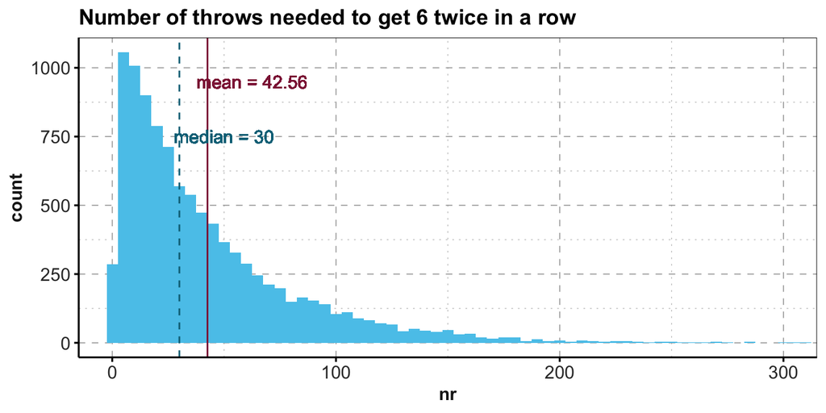

```r
library(tidyverse)
library(unikn)

# Turn out into a tibble:
tb <- tibble(nr = out)
# tb

# Histogram of individual number of throws:
ggplot(tb) +
  geom_histogram(aes(x = nr), binwidth = 5, fill = Seeblau) +
  # Show mean and median:
  geom_vline(xintercept = mean(out), linetype = 1, color = Bordeaux) +  # mean line
  geom_text(label = paste0("mean = ", round(mean(out), 2)), x = mean(out) + 20, y = 950, color = Bordeaux) +    # mean label
  geom_vline(xintercept = median(out), linetype = 2, color = Petrol) +  # median line
  geom_text(label = paste0("median = ", round(median(out), 2)), x = median(out) + 20, y = 750, color = Petrol) +  # mean label
  # Text and formatting:
  labs(title = "Number of throws needed to get 6 twice in a row") +
  coord_cartesian(xlim = c(0, 300)) +  # do not show values beyond x = 300
  theme_unikn(col_title = "black")
```

## Exercise 4

Write code that uses a function of the **base** R `apply` or **purrr** `map` family of functions to:

1. Compute the mean of every column in `mtcars`.
2. Determine the type of each column in `ggplot2::diamonds`.
3. Compute the number of unique values in each column of `iris`.
4. Generate 10 random normal numbers for each of `μ = −100, 0, and 100`.

**Note:** This exercise is based on **Exercise 1** of [Chapter 21.5.3](https://r4ds.had.co.nz/iteration.html#exercises-58) in [r4ds](https://r4ds.had.co.nz/).

```r
# 1. Compute the mean of every column in `mtcars`:

# (a) Solve for 1st column:
mean(mtcars$mpg)
```

```
#> [1] 20.09062
```

```r
# (b) Generalize to all columns:
as_tibble(mtcars) %>% map_dbl(mean)
```

```
#>        mpg        cyl       disp         hp       drat         wt
#>  20.090625   6.187500 230.721875 146.687500   3.596563   3.217250
#>       qsec         vs         am       gear       carb
#>  17.848750   0.437500   0.406250   3.687500   2.812500
```

```r
apply(X = mtcars, MARGIN = 2, FUN = mean)
```

```
#>        mpg        cyl       disp         hp       drat         wt
#>  20.090625   6.187500 230.721875 146.687500   3.596563   3.217250
#>       qsec         vs         am       gear       carb
#>  17.848750   0.437500   0.406250   3.687500   2.812500
```

```r
# 2. Determine the type of each column in `ggplot2::diamonds`:

# (a) Solve for 1st column:
typeof(ggplot2::diamonds$carat)  # solution for 1st column
```

```
#> [1] "double"
```

```r
# (b) Generalize to all columns:
ggplot2::diamonds %>% map_chr(typeof)
```

```
#>     carat       cut     color   clarity     depth     table     price
#>  "double" "integer" "integer" "integer"  "double"  "double" "integer"
#>         x         y         z
#>  "double"  "double"  "double"
```

```r
apply(X = ggplot2::diamonds, MARGIN = 2, FUN = typeof)
```

```
#>       carat         cut       color     clarity       depth       table
#> "character" "character" "character" "character" "character" "character"
#>       price           x           y           z
#> "character" "character" "character" "character"
```

```r
# Note: All variables viewed as characters!

# 3. Compute the number of unique values in each column of `iris`:

# (a) Solve for 1st column:
n_distinct(iris$Sepal.Length)  # solution for 1st column
```

```
#> [1] 35
```

```r
# (b) Generalize to all columns:
as_tibble(iris) %>% map_int(n_distinct)
```

```
#> Sepal.Length  Sepal.Width Petal.Length  Petal.Width      Species
#>           35           23           43           22            3
```

```r
apply(X = iris, MARGIN = 2, FUN = n_distinct)
```

```
#> Sepal.Length  Sepal.Width Petal.Length  Petal.Width      Species
#>           35           23           43           22            3
```

```r
# 4. Generate 10 random normal numbers for each of `μ = −100, 0, and 100`:

# (a) Solve for 1st mean:
mu <- c(-100, 0, 100)
rnorm(n = 10, mean = mu[1])
```

```
#>  [1]  -99.97310 -101.54320  -98.07826 -100.36087 -100.35630 -100.78901
#>  [7]  -99.65389  -99.47523  -99.42435  -98.26227
```

```r
# (b) Generalize to all means:
mu %>% map(rnorm, n = 10) %>% str()
```

```
#> List of 3
#>  $ : num [1:10] -99.4 -100.2 -100.1 -100.4 -98.3 ...
#>  $ : num [1:10] -0.21 1.582 0.944 0.599 0.466 ...
#>  $ : num [1:10] 97.8 97.6 100.8 100.9 101.3 ...
```

```r
lapply(X = mu, FUN = rnorm, n = 10) %>% str()
```

```
#> List of 3
#>  $ : num [1:10] -100.6 -99.4 -98.7 -99 -100.1 ...
#>  $ : num [1:10] 1.901 -0.615 -0.44 -0.231 0.72 ...
#>  $ : num [1:10] 101.4 100.3 100.4 99.8 99.8 ...
```

```r
# Note: In 4(b), we add str() to show the structure of the output lists.
```

## Exercise 5

#### Z-transforming tables

In this exercise, we will standardize an entire table of data (using a `for` loop, an `apply`, and a `map` function). We will first write a utility function that achieves the desired transformation for a vector and then compare and contrast different ways of applying this function to a table of data.

In case you are not familiar with the notion of a *z score* or *standard score*, look up these terms (e.g., [on Wikipedia](https://en.wikipedia.org/wiki/Standard_score)).

1. Write a function called `z_trans` that takes a vector `v` as input and returns the z-transformed (or standardized) values as output if `v` is numeric and returns `v` unchanged if it is non-numeric.

**Hint:** Remember that `z <- (v - mean(v)) / sd(v))`, but beware that `v` could contain `NA` values.

```r
z_trans <- function(v) {

    if (!is.numeric(v)) {
      message("v is not numeric: Leaving as is...")
      return(v)
    }

    if (NA %in% v) {
      warning("v contains NA-values (ignored here).")
    }

    result <- (v - mean(v, na.rm = TRUE)) / sd(v, na.rm = TRUE)

    return(result)
}

# Check:
z_trans(v = c(-10:10))
```

```
#>  [1] -1.6116459 -1.4504813 -1.2893167 -1.1281521 -0.9669876 -0.8058230
#>  [7] -0.6446584 -0.4834938 -0.3223292 -0.1611646  0.0000000  0.1611646
#> [13]  0.3223292  0.4834938  0.6446584  0.8058230  0.9669876  1.1281521
#> [19]  1.2893167  1.4504813  1.6116459
```

```r
z_trans(v = c(-1, NA, 1))
```

```
#> [1] -0.7071068         NA  0.7071068
```

```r
z_trans(v = letters[1:5])
```

```
#> [1] "a" "b" "c" "d" "e"
```

```r
z_trans(v = (1:4 > 2))
```

```
#> [1] FALSE FALSE  TRUE  TRUE
```

2. Load the *false positive psychology* data (at http://rpository.com/ds4psy/data/falsePosPsy_all.csv) into `falsePosPsy` and remove any non-numeric variables from it.

```r
falsePosPsy <- read_csv(file = "http://rpository.com/ds4psy/data/falsePosPsy_all.csv")
falsePosPsy
```

```
#> # A tibble: 78 x 19
#>    study    ID  aged aged365 female   dad   mom potato when64 kalimba cond
#>    <dbl> <dbl> <dbl>   <dbl>  <dbl> <dbl> <dbl>  <dbl>  <dbl>   <dbl> <chr>
#>  1     1     1  6765    18.5      0    49    45      0      0       1 cont…
#>  2     1     2  7715    21.1      1    63    62      0      1       0 64
#>  3     1     3  7630    20.9      0    61    59      0      1       0 64
#>  4     1     4  7543    20.7      0    54    51      0      0       1 cont…
#>  5     1     5  7849    21.5      0    47    43      0      1       0 64
#>  6     1     6  7581    20.8      1    49    50      0      1       0 64
#>  7     1     7  7534    20.6      1    56    55      0      0       1 cont…
#>  8     1     8  6678    18.3      1    45    45      0      1       0 64
#>  9     1     9  6970    19.1      0    53    51      1      0       0 pota…
#> 10     1    10  7681    21.0      0    53    51      0      1       0 64
#> # … with 68 more rows, and 8 more variables: root <dbl>, bird <dbl>,
#> #   political <dbl>, quarterback <dbl>, olddays <dbl>, feelold <dbl>,
#> #   computer <dbl>, diner <dbl>
```

- Use an appropriate `map` function to to create a single vector that — for each column in `falsePosPsy` — indicates whether or not it is a numeric variable?

**Hint:** The function `is.numeric` tests whether a vector is numeric.

```r
# (a) Solve for individual variables:
is.numeric(falsePosPsy$kalimba)
```

```
#> [1] TRUE
```

```r
is.numeric(falsePosPsy$cond)
```

```
#> [1] FALSE
```

```r
# (b) Generalize to entire table:
numeric_cols <- falsePosPsy %>% map_lgl(is.numeric)
numeric_cols
```

```
#>       study          ID        aged     aged365      female         dad
#>        TRUE        TRUE        TRUE        TRUE        TRUE        TRUE
#>         mom      potato      when64     kalimba        cond        root
#>        TRUE        TRUE        TRUE        TRUE       FALSE        TRUE
#>        bird   political quarterback     olddays     feelold    computer
#>        TRUE        TRUE        TRUE        TRUE        TRUE        TRUE
#>       diner
#>        TRUE
```

- Use this vector to select only the numeric columns of `falsePosPsy` into a new tibble `fpp_numeric`:

```r
# Indexing columns of falsePosPsy by numeric_cols:
fpp_numeric <- falsePosPsy[ , numeric_cols]
# fpp_numeric

# Alternative solution:
fpp_numeric_1 <- falsePosPsy[, map_lgl(falsePosPsy, is.numeric)]
all.equal(fpp_numeric, fpp_numeric_1)
```

```
#> [1] TRUE
```

```r
# Using dplyr::select:
fpp_numeric_2 <- falsePosPsy %>% dplyr::select(-cond)  # notice that `cond` is non-numeric
all.equal(fpp_numeric, fpp_numeric_2)
```

```
#> [1] TRUE
```

- Use a `for` loop to apply your `z_trans` function to `fpp_numeric` to standardize all of its columns:

```r
out <- c()  # prepare output vector

# for loop:
for (i in seq_along(fpp_numeric)){

  out <- cbind(out, z_trans(fpp_numeric[[i]]))

}

# Result:
# out
```

- Turn your resulting data structure into a tibble `out_1` and print it.

```r
# Print result (as tibble):
out_1 <- as_tibble(out)
out_1
```

```
#> # A tibble: 78 x 18
#>        V1    V2      V3      V4     V5      V6      V7     V8     V9    V10
#>     <dbl> <dbl>   <dbl>   <dbl>  <dbl>   <dbl>   <dbl>  <dbl>  <dbl>  <dbl>
#>  1 -0.873 -1.70 -0.902  -0.902  -0.873 -0.756  -1.13   -0.807 -0.682  1.59
#>  2 -0.873 -1.65  0.128   0.128   1.13   2.02    2.11   -0.807  1.45  -0.623
#>  3 -0.873 -1.61  0.0362  0.0362 -0.873  1.63    1.54   -0.807  1.45  -0.623
#>  4 -0.873 -1.57 -0.0582 -0.0582 -0.873  0.237   0.0171 -0.807 -0.682  1.59
#>  5 -0.873 -1.52  0.274   0.274  -0.873 -1.15   -1.51   -0.807  1.45  -0.623
#>  6 -0.873 -1.48 -0.0170 -0.0170  1.13  -0.756  -0.173  -0.807  1.45  -0.623
#>  7 -0.873 -1.43 -0.0680 -0.0680  1.13   0.634   0.779  -0.807 -0.682  1.59
#>  8 -0.873 -1.39 -0.996  -0.996   1.13  -1.55   -1.13   -0.807  1.45  -0.623
#>  9 -0.873 -1.35 -0.680  -0.680  -0.873  0.0382  0.0171  1.22  -0.682 -0.623
#> 10 -0.873 -1.30  0.0915  0.0915 -0.873  0.0382  0.0171 -0.807  1.45  -0.623
#> # … with 68 more rows, and 8 more variables: V11 <dbl>, V12 <dbl>,
#> #   V13 <dbl>, V14 <dbl>, V15 <dbl>, V16 <dbl>, V17 <dbl>, V18 <dbl>
```

Note that we use `cbind` rather than `c` within the `for` loop to add the results of `z_trans` to `out`. This is because `z_trans` returns a *vector* for every column of `only_numeric`. Alternatively, we also could have constructed a very long vector (with a length of `nrow(fpp_numeric) x ncol(fpp_numeric)` = 78 x 18 = 1404) and turned it into a rectangular table later.

3. Repeat the task of 2. (i.e., applying `z_trans` to all numeric columns of `falsePosPsy`) by using the **base** R `apply` function, rather than a `for` loop. Save and print your resulting data structure as a tibble `out_2`.

**Hint:** Remember to set the `MARGIN` argument to apply `z_trans` over all *columns*, rather than *rows*.

```r
# Data:
# fpp_numeric

out_2 <- apply(X = fpp_numeric, MARGIN = 2, FUN = z_trans)

# Print result (as tibble):
out_2 <- as_tibble(out_2)
out_2
```

```
#> # A tibble: 78 x 18
#>     study    ID    aged aged365 female     dad     mom potato when64
#>     <dbl> <dbl>   <dbl>   <dbl>  <dbl>   <dbl>   <dbl>  <dbl>  <dbl>
#>  1 -0.873 -1.70 -0.902  -0.902  -0.873 -0.756  -1.13   -0.807 -0.682
#>  2 -0.873 -1.65  0.128   0.128   1.13   2.02    2.11   -0.807  1.45
#>  3 -0.873 -1.61  0.0362  0.0362 -0.873  1.63    1.54   -0.807  1.45
#>  4 -0.873 -1.57 -0.0582 -0.0582 -0.873  0.237   0.0171 -0.807 -0.682
#>  5 -0.873 -1.52  0.274   0.274  -0.873 -1.15   -1.51   -0.807  1.45
#>  6 -0.873 -1.48 -0.0170 -0.0170  1.13  -0.756  -0.173  -0.807  1.45
#>  7 -0.873 -1.43 -0.0680 -0.0680  1.13   0.634   0.779  -0.807 -0.682
#>  8 -0.873 -1.39 -0.996  -0.996   1.13  -1.55   -1.13   -0.807  1.45
#>  9 -0.873 -1.35 -0.680  -0.680  -0.873  0.0382  0.0171  1.22  -0.682
#> 10 -0.873 -1.30  0.0915  0.0915 -0.873  0.0382  0.0171 -0.807  1.45
#> # … with 68 more rows, and 9 more variables: kalimba <dbl>, root <dbl>,
#> #   bird <dbl>, political <dbl>, quarterback <dbl>, olddays <dbl>,
#> #   feelold <dbl>, computer <dbl>, diner <dbl>
```

4. Repeat the task of 2. and 3. (i.e., applying `z_trans` to all numeric columns of `falsePosPsy`) by using an appropriate version of a `map` function from the **purrr** package. Save and print your resulting data structure as a tibble `out_3`.

**Hint:** Note that the desired output structure is a rectangular data table, which is also a *list*.

```r
# Data:
# fpp_numeric

# Using map to return a list:
out_3 <- purrr::map(.x = fpp_numeric, .f = z_trans)

# Print result (as tibble):
out_3 <- as_tibble(out_3)
out_3
```

```
#> # A tibble: 78 x 18
#>     study    ID    aged aged365 female     dad     mom potato when64
#>     <dbl> <dbl>   <dbl>   <dbl>  <dbl>   <dbl>   <dbl>  <dbl>  <dbl>
#>  1 -0.873 -1.70 -0.902  -0.902  -0.873 -0.756  -1.13   -0.807 -0.682
#>  2 -0.873 -1.65  0.128   0.128   1.13   2.02    2.11   -0.807  1.45
#>  3 -0.873 -1.61  0.0362  0.0362 -0.873  1.63    1.54   -0.807  1.45
#>  4 -0.873 -1.57 -0.0582 -0.0582 -0.873  0.237   0.0171 -0.807 -0.682
#>  5 -0.873 -1.52  0.274   0.274  -0.873 -1.15   -1.51   -0.807  1.45
#>  6 -0.873 -1.48 -0.0170 -0.0170  1.13  -0.756  -0.173  -0.807  1.45
#>  7 -0.873 -1.43 -0.0680 -0.0680  1.13   0.634   0.779  -0.807 -0.682
#>  8 -0.873 -1.39 -0.996  -0.996   1.13  -1.55   -1.13   -0.807  1.45
#>  9 -0.873 -1.35 -0.680  -0.680  -0.873  0.0382  0.0171  1.22  -0.682
#> 10 -0.873 -1.30  0.0915  0.0915 -0.873  0.0382  0.0171 -0.807  1.45
#> # … with 68 more rows, and 9 more variables: kalimba <dbl>, root <dbl>,
#> #   bird <dbl>, political <dbl>, quarterback <dbl>, olddays <dbl>,
#> #   feelold <dbl>, computer <dbl>, diner <dbl>
```

5. Use `all.equal` to verify that your results of 2., 3. and 4. (i.e., `out_1`, `out_2`, and `out_3`) are all equal.

**Hint:** If a tibble `t1` lacks variable names, you can add those of another tibble `t2` by assigning `names(t1) <- names(t2)`.

```r
# Note that out_1 did not retain the variable names of `fpp_numeric`:
names(out_1) <- names(fpp_numeric)  # re-adding names to out_1

# Verify equality:
all.equal(out_1, out_2)
```

```
#> [1] TRUE
```

```r
all.equal(out_2, out_3)
```

```
#> [1] TRUE
```

# Additional resources

## Resources on iteration

- See [Chapter 21: Iteration](https://r4ds.had.co.nz/iteration.html) of [r4ds](https://r4ds.had.co.nz/) and its exercises.
- For loops in general, see the [contributed cheatsheets](https://www.rstudio.com/resources/cheatsheets/) on *Base R* and *Advanced R*.

## Resources on functional programming

- For references on functional programming (FP) with **purrr**, see https://purrr.tidyverse.org and the [purrr cheatsheet](https://www.rstudio.com/resources/cheatsheets/).
- The book [Advanced R](http://adv-r.had.co.nz/) contains several chapters on functional programming.

# Conclusion

All [ds4psy](http://rpository.com/ds4psy/) essentials so far:

| Nr. | Topic |
| --- | --- |
| 0. | [Syllabus](http://rpository.com/ds4psy/) |
| 1. | [Basic R concepts and commands](http://rpository.com/ds4psy/essentials/basics.html) |
| 2. | [Visualizing data](http://rpository.com/ds4psy/essentials/visualize.html) |
| 3. | [Transforming data](http://rpository.com/ds4psy/essentials/transform.html) |
| 4. | [Exploring data (EDA)](http://rpository.com/ds4psy/essentials/explore.html) |
| 5. | [Tibbles](http://rpository.com/ds4psy/essentials/tibbles.html) |
| 6. | [Importing data](http://rpository.com/ds4psy/essentials/import.html) |
| 7. | [Tidying data](http://rpository.com/ds4psy/essentials/tidy.html) |
| 8. | [Joining data](http://rpository.com/ds4psy/essentials/join.html) |
| 9. | [Functions](http://rpository.com/ds4psy/essentials/function.html) |
| 10. | **Iteration** |
| +. | [Datasets](http://rpository.com/ds4psy/essentials/datasets.html) |

[Last update on 2019-07-08 10:45:18 by [hn](https://neth.de/).]